# ggplot2

**ggplot2** is a system for creating graphics based on The Grammar of Graphics:

- Provide the data.
- tell ggplot2 how to map variables to aesthetics.
- tell what graphical primitives to use.

```r
library(dplyr)
library(data.table)
library(ggplot2)
```

# 1 Some data to plot

We will analyze depart and arrival delays frow airports in New York City in 2014. Our data looks like:

```r
flights <- fread("https://raw.githubusercontent.com/Rdatatable/data.table/master/vignettes/flights14.csv")
flights
```

```
##         year month day dep_delay arr_delay carrier origin dest air_time
##      1: 2014     1   1        14        13      AA    JFK  LAX      359
##      2: 2014     1   1        -3        13      AA    JFK  LAX      363
##      3: 2014     1   1         2         9      AA    JFK  LAX      351
##      4: 2014     1   1        -8       -26      AA    LGA  PBI      157
##      5: 2014     1   1         2         1      AA    JFK  LAX      350
##     ---
## 253312: 2014    10  31         1       -30      UA    LGA  IAH      201
## 253313: 2014    10  31        -5       -14      UA    EWR  IAH      189
## 253314: 2014    10  31        -8        16      MQ    LGA  RDU       83
## 253315: 2014    10  31        -4        15      MQ    LGA  DTW       75
## 253316: 2014    10  31        -5         1      MQ    LGA  SDF      110
##         distance hour
##      1:     2475    9
##      2:     2475   11
##      3:     2475   19
##      4:     1035    7
##      5:     2475   13
##     ---
## 253312:     1416   14
## 253313:     1400    8
## 253314:      431   11
## 253315:      502   11
## 253316:      659    8
```

```r
names(flights)
```

```
##  [1] "year"      "month"     "day"       "dep_delay" "arr_delay"
##  [6] "carrier"   "origin"    "dest"      "air_time"  "distance"
## [11] "hour"
```

We can do that using `data.table`:

```r
av_delays <- flights[!is.na(dep_delay) & !is.na(arr_delay) , .(av_dep=mean(dep_delay), av_arr=mean(arr_delay), traffic=.N), by=  .(year, month, day, hour, origin)]
```

… or using `dplyr`:

```r
av_delays.dp <- flights %>% filter(!is.na(dep_delay) & !is.na(arr_delay)) %>% group_by(year, month, day, hour, origin) %>% summarise(av_dep=mean(dep_delay), av_arr=mean(arr_delay), traffic=n())
```

To obtain a **ggplot** graph we need:

- to pass the data and map the aesthetics with the **ggplot** function
- to tell the primitives to use.

As we will see, each primitive is associated to an aesthetic. We could use either `data.table`, `data.frame` or `tibble` as input of a ggplot graphic.

We can select a color by a number or a name from `colors()` ([color chart](http://research.stowers.org/mcm/efg/R/Color/Chart/ColorChart.pdf)) or using other codes like HEX.

We can get different types of graphs for **one variable**, **discrete variable, continuous variable**, **two continuous variables**, create **facet grids** and **interactive plots**. We could aslo create animations with `gganimate` as we’ll see with maps.

# 2 One variable

## 2.1 Barplots: `geom_bar()

We can use barplots to visualize categorical variables. In a `barplot`, we count how many elements are in each category. For instance, we can count how many flights are flown by each carrier. To do so we use the original `flights` dataset. Note that the aesthetic is a categorical variable, and `ggplot` counts how many elements there are to make the barplot.

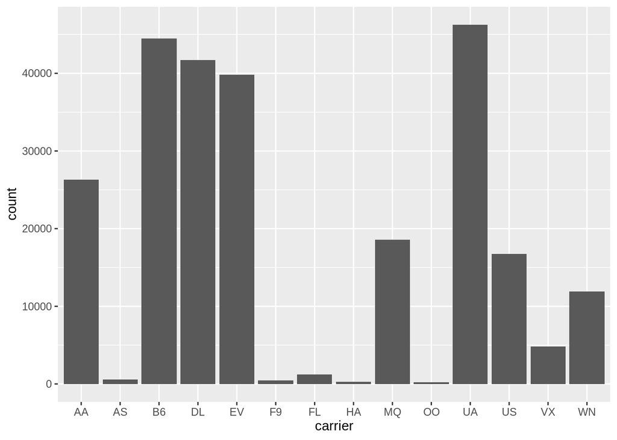

```r
ggplot(flights, aes(carrier)) + geom_bar()
```

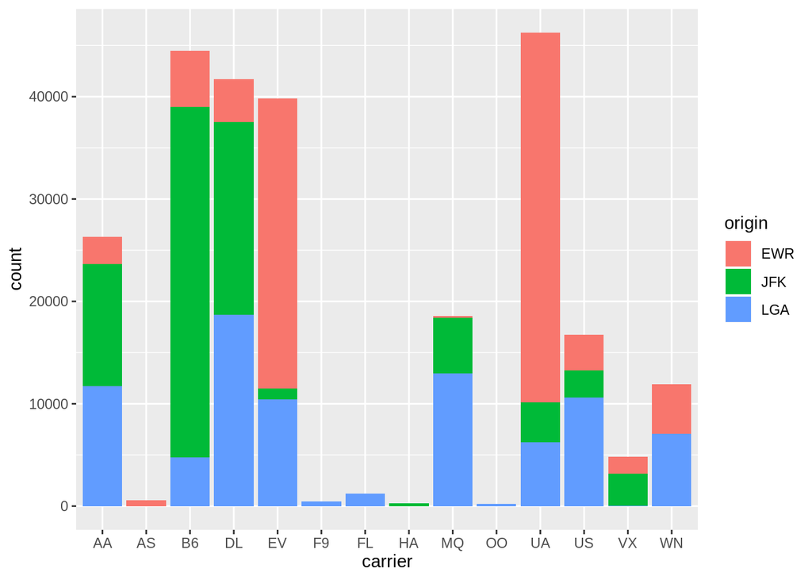

```r
ggplot(flights, aes(carrier, fill=origin)) + geom_bar()
```

We can have different presentations using the `position` variable in `geom_bar`.

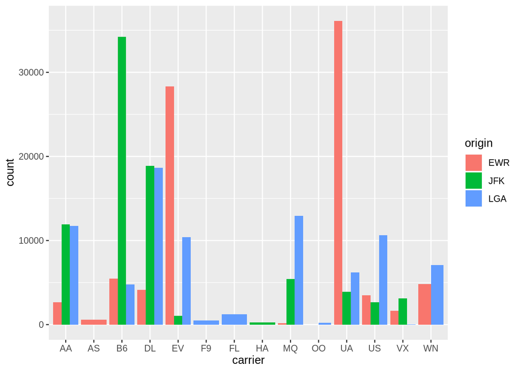

```r
ggplot(flights, aes(carrier, fill=origin)) + geom_bar(position = "dodge")
```

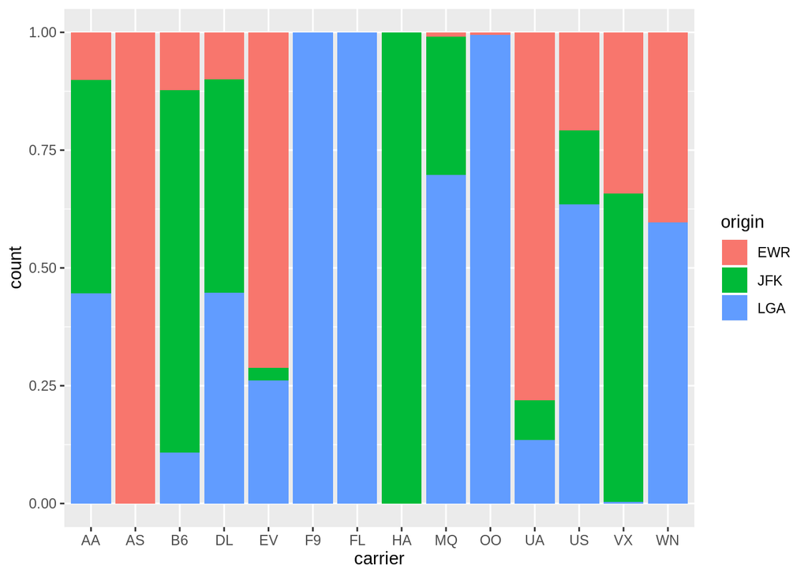

```r
ggplot(flights, aes(carrier, fill=origin)) + geom_bar(position = "fill")
```

## 2.2 Histograms: `geom_histogram()`

An `histogram` may look like a barplot, but presents quite different information. We use histograms to examine the distribution of a variable. Each bin of the histogram represents an interval of possible values of the variable. The height of each bin is equal to the number of elements of the dataset that have values within the interval. Here we are plotting an histogram of the distribution of the `av_dep` variable.

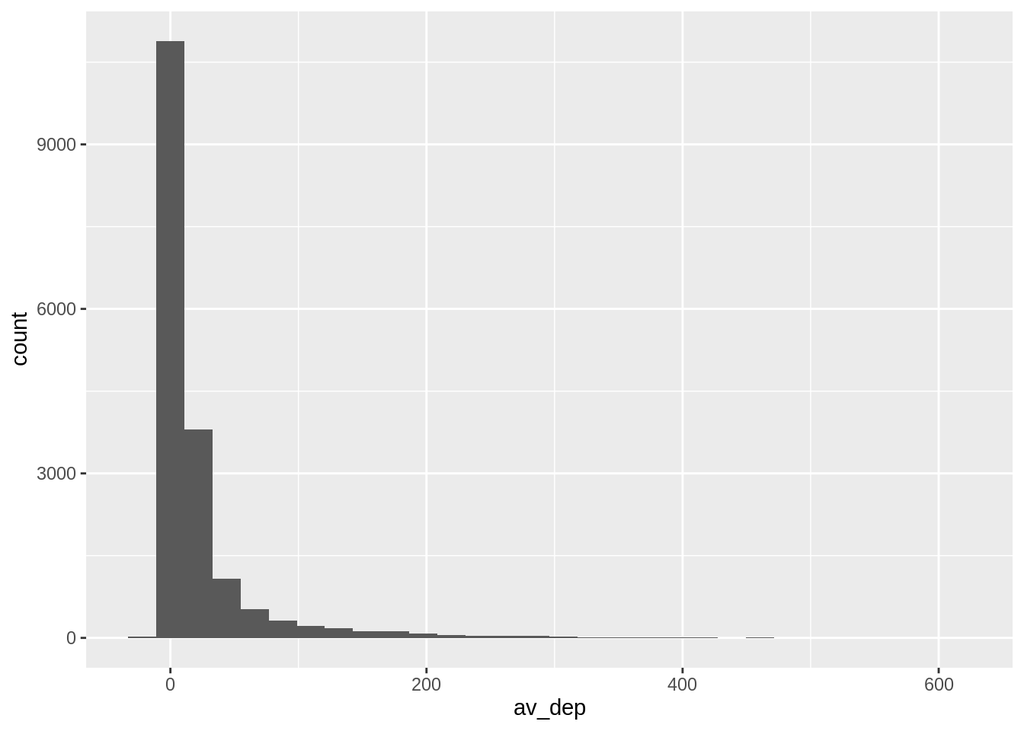

```r
ggplot(av_delays, aes(av_dep)) + geom_histogram()
```

## 2.3 One-dimension density plots: `geom_density()`

A `density` is an histogram whose bins are of infinitesimal width. Note the similarity of this plot of the distribution of `av_dep` with the previous histogram.

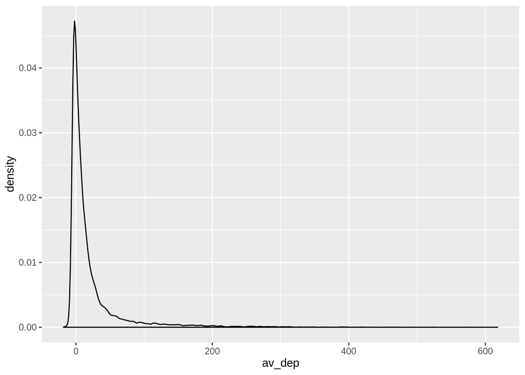

```r
ggplot(av_delays, aes(av_dep)) + geom_density()
```

We can modify the graphical parameters, with a lines in blue and density fill in green:

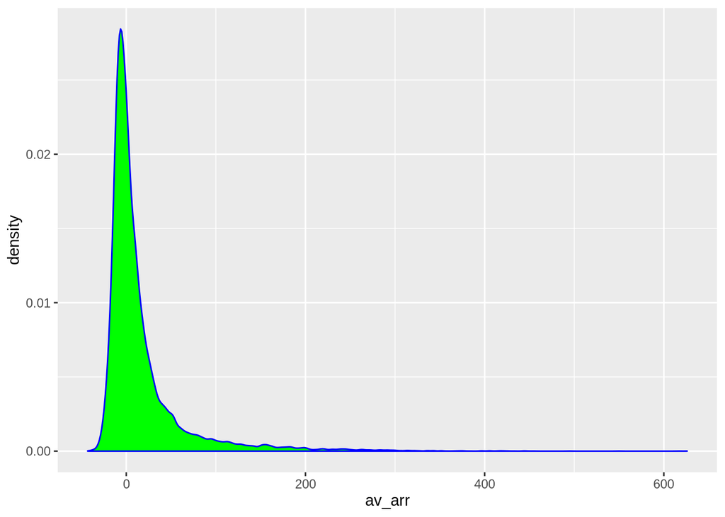

```r
ggplot(av_delays, aes(av_arr)) + geom_density(color = "blue", fill = "green")
```

We now also change the `theme`:

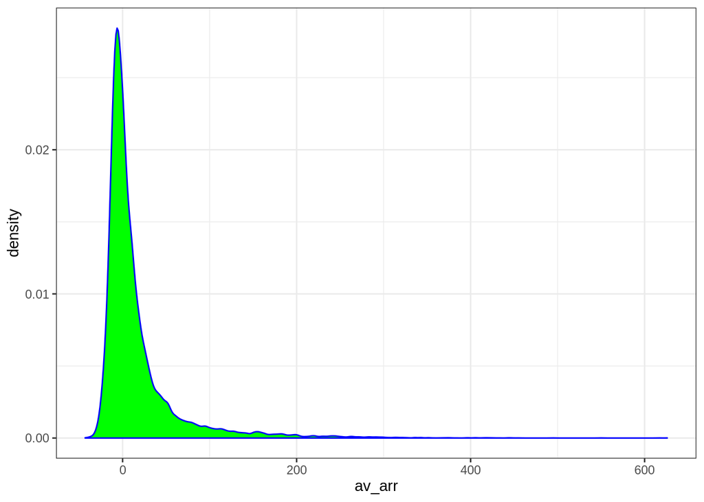

```r
ggplot(av_delays, aes(av_arr)) + geom_density(color = "blue", fill = "green") + theme_bw()
```

With a larger font size:

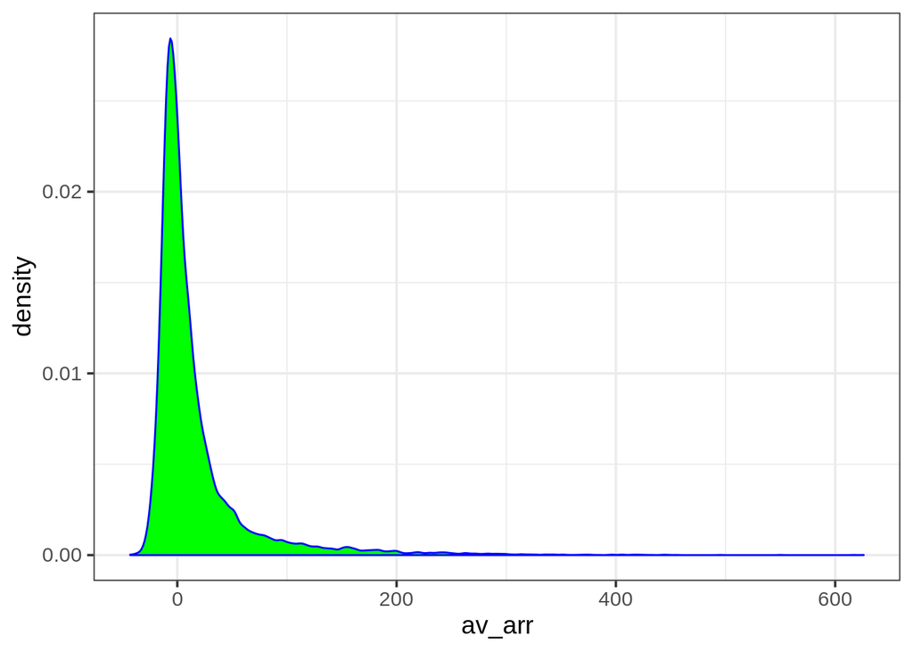

```r
ggplot(av_delays, aes(av_arr)) + geom_density(color = "blue", fill = "green") + theme_bw(base_size = 14)
```

# 3 Discrete variable, continuous variable

We can evaluate a continuous variable, say `av_arr` as a function of a categorical variable, the `origin` airport.

## 3.1 Barplots: `geom_bar()`

In the previous sections, we have used barplots to count how many elements fall within a categorical variable. We can use `geom_bar` with a esthetic including a categorical variable (`origin`) and a integer variable (`traffic`) to sum up the traffic in each airport:

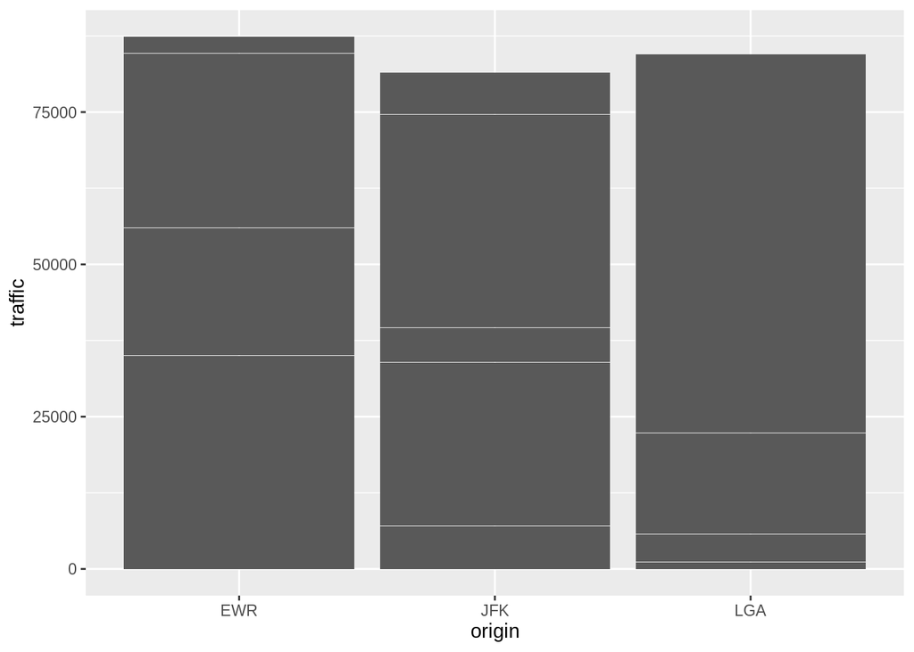

```r
ggplot(av_delays, aes(origin, traffic)) + geom_bar(stat = "identity")
```

## 3.2 Boxplots: `geom_boxplot()`

A `boxplot` shows data distribution of a variable through its position statistics:

- first quartile **Q1**: value of the lowest 25% observation of the variable.
- second quartile **Q2** or **median**: value of the observation lying in the 50% of the variable.
- third quartile **Q3**: value of the lowest 75% observation of the variable.

Here is a boxplot for the `av_arr` variable for each category:

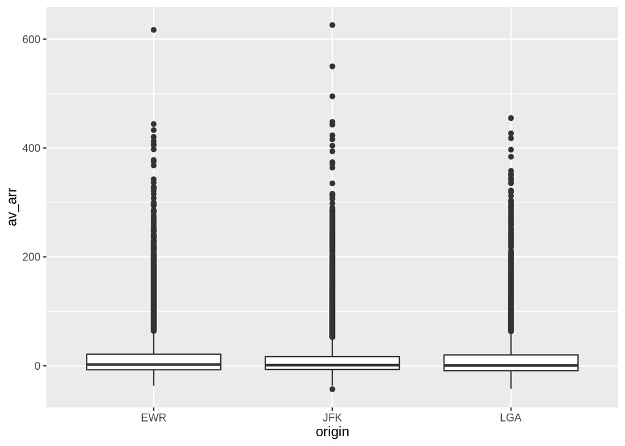

```r
ggplot(av_delays, aes(origin, av_arr)) + geom_boxplot()
```

Let’s control the `y limit` so we can appreciate the plot:

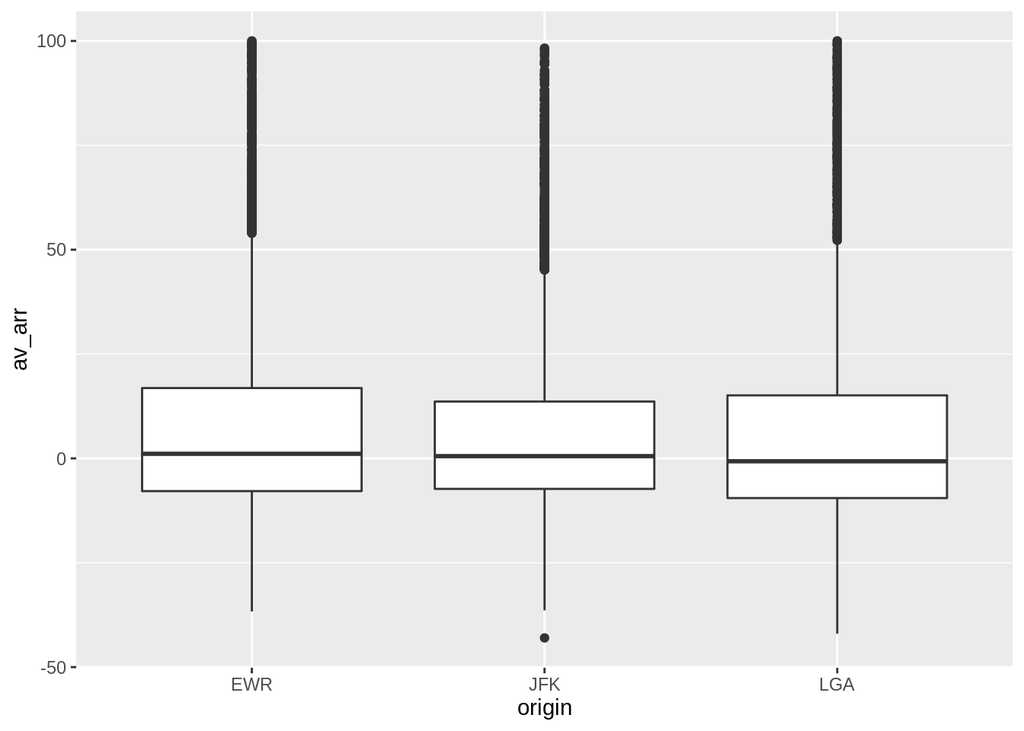

```r
ggplot(av_delays, aes(origin, av_arr)) + geom_boxplot() +
  ylim(c(min(av_delays$av_arr), 100))
```

### 3.2.1 Violin plots: `geom_violin()`

A `violin plot` presents a symmetrical picture of the distribution of the variable for each category, similar to the one that we can obtain with `geom_density()`:

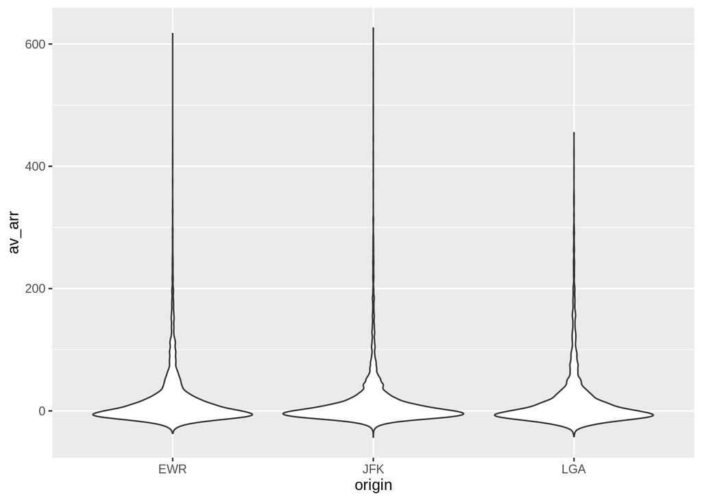

```r
ggplot(av_delays, aes(origin, av_arr)) + geom_violin()
```

Adding `color` and changing the `theme`:

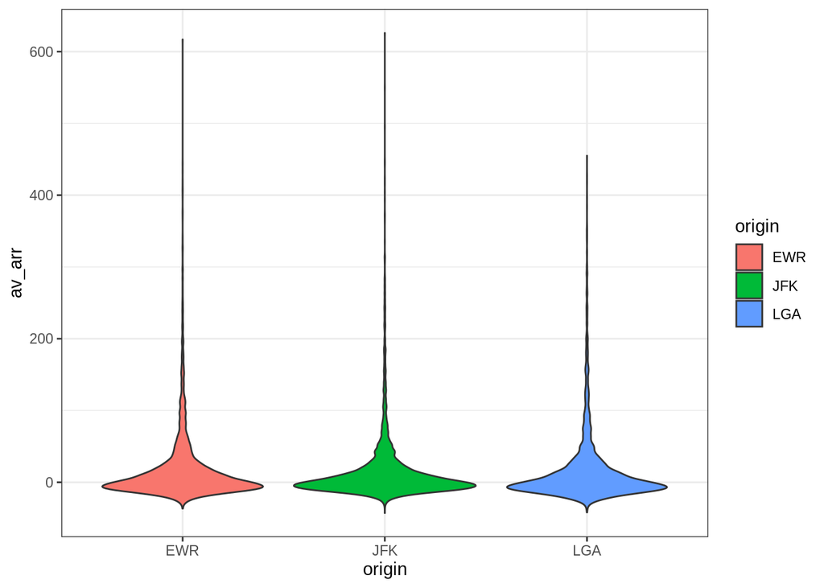

```r
ggplot(av_delays, aes(origin, av_arr, fill=origin)) + geom_violin() + theme_bw()
```

# 4 Two continuous variables

## 4.1 Scatterplots: `geom_point()`

We can be interested in checking the relationship between arrival and departure delays for each hour segment, so every observation is a point in a scatterplot. We can also let ggplot draw a tendency line with `geom_smooth`:

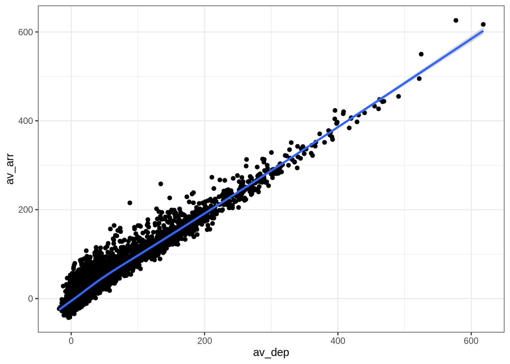

```r
ggplot(av_delays, aes(av_dep, av_arr)) + geom_point() + geom_smooth() + theme_bw()
```

And we can do the same for each origin, plotting it in a different color:

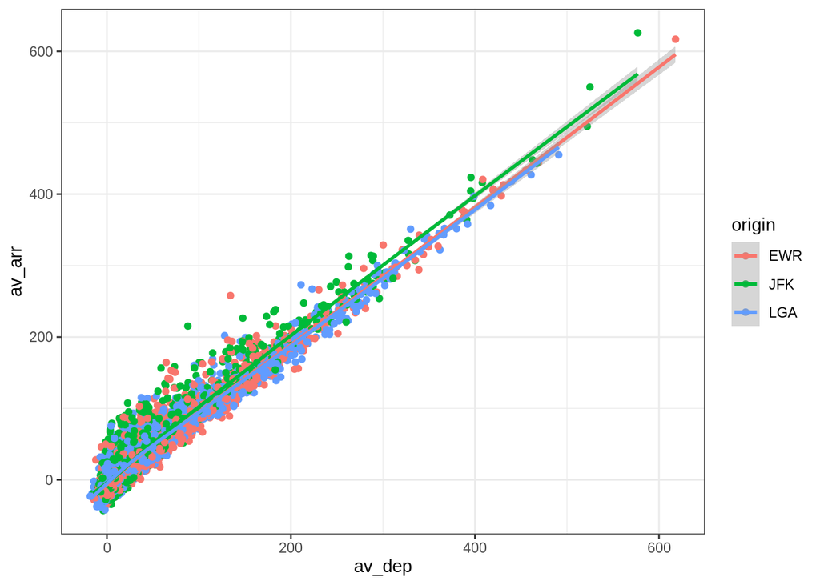

```r
ggplot(av_delays, aes(av_dep, av_arr, color=origin)) + geom_point() + geom_smooth() + theme_bw()
```

We can also set several labels, titles and captions with `lab`:

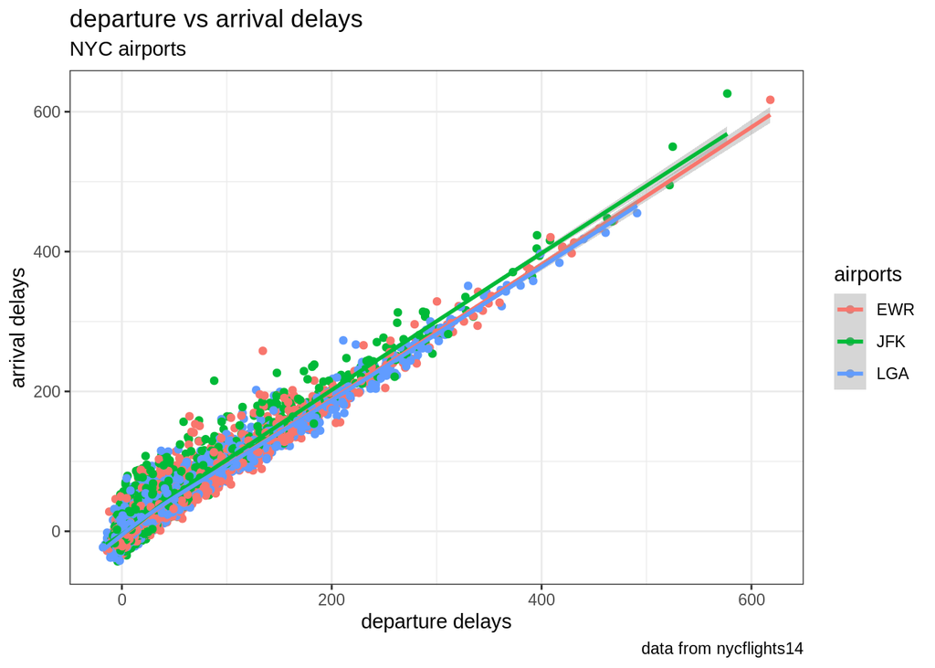

```r
ggplot(av_delays, aes(av_dep, av_arr, color=origin)) + geom_point() + geom_smooth() + theme_bw() + labs(title="departure vs arrival delays", subtitle="NYC airports", colour="airports", caption="data from nycflights14", x="departure delays", y="arrival delays")
```

## 4.2 Continuous functions: `geom_line()`

We can also plot the evolution of a function using a set of points using `geom_line()`. First we obtain a `time variable in R time format:

```r
av_delays[, time := strptime(paste0(year, "-", month, "-", day, " ", hour), format = "%Y-%m-%d %H", tz = "GMT")]
```

Then we can plot the evolution of arrival delays with time:

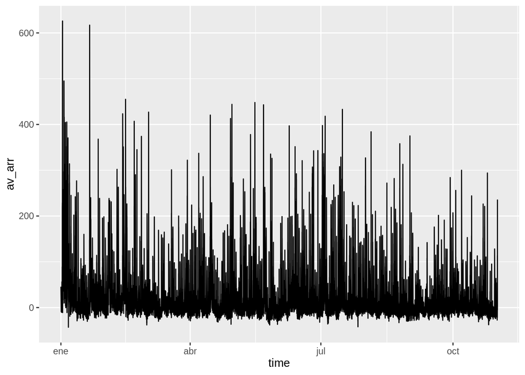

```r
ggplot(av_delays, aes(time, av_arr)) + geom_line()
```

## 4.3 Two-density plots: `geom_density_2d()`

Similarly to one-density plots, we can draw density plots of bivariates:

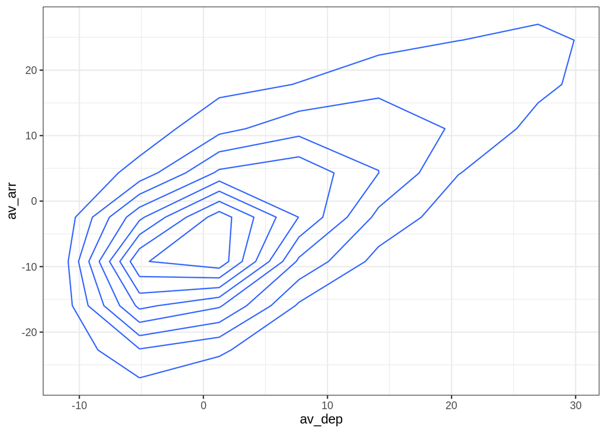

```r
ggplot(av_delays, aes(av_dep, av_arr)) + geom_density_2d() + theme_bw()
```

# 5 Facet grids: `facet_grid()`

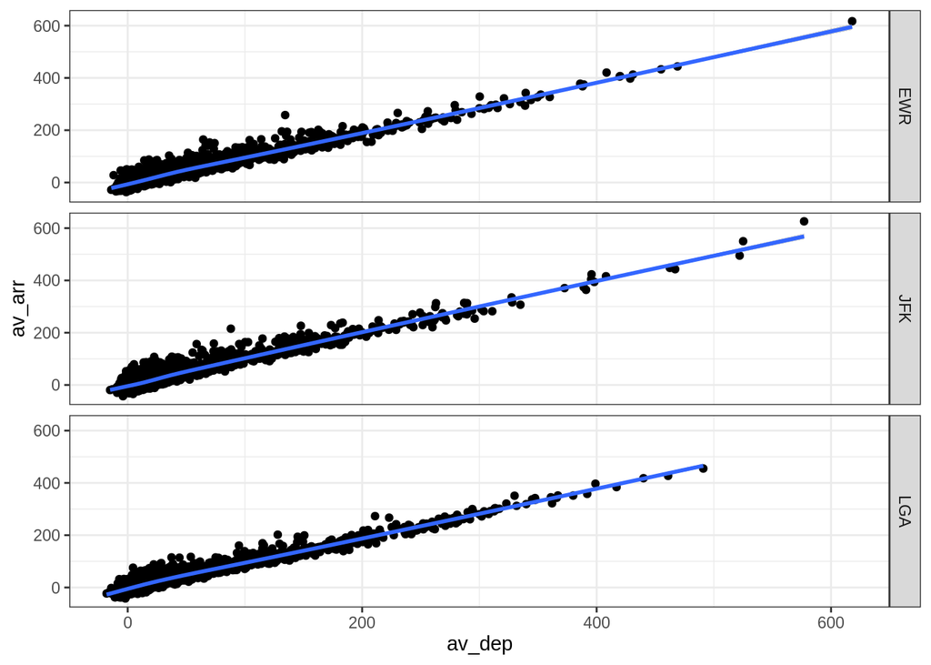

```r
ggplot(av_delays, aes(av_dep, av_arr)) + geom_point() + geom_smooth() + theme_bw() + facet_grid(origin ~ .)
```

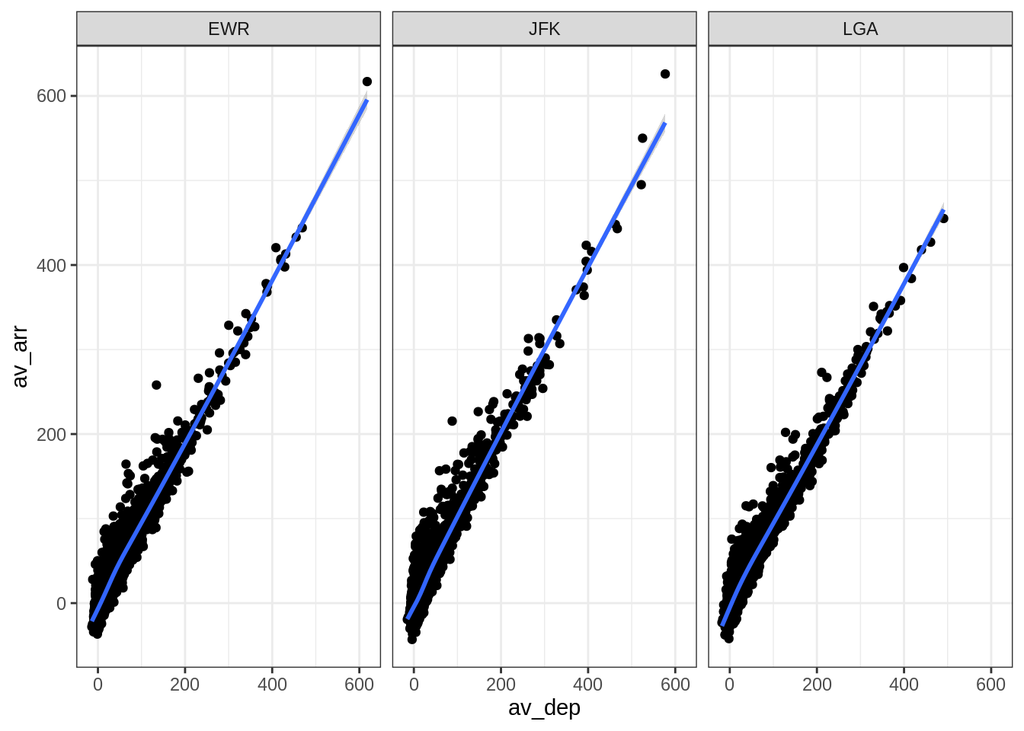

```r
ggplot(av_delays, aes(av_dep, av_arr)) + geom_point() + geom_smooth() + theme_bw() + facet_grid(. ~ origin)
```

An advantage of using tydiverse functions is that we can arrange data and make the plot with a single instruction. Here we are using `select` from `dplyr`, `gather` from `tidyr` and `ggplot2` functions in a single call:

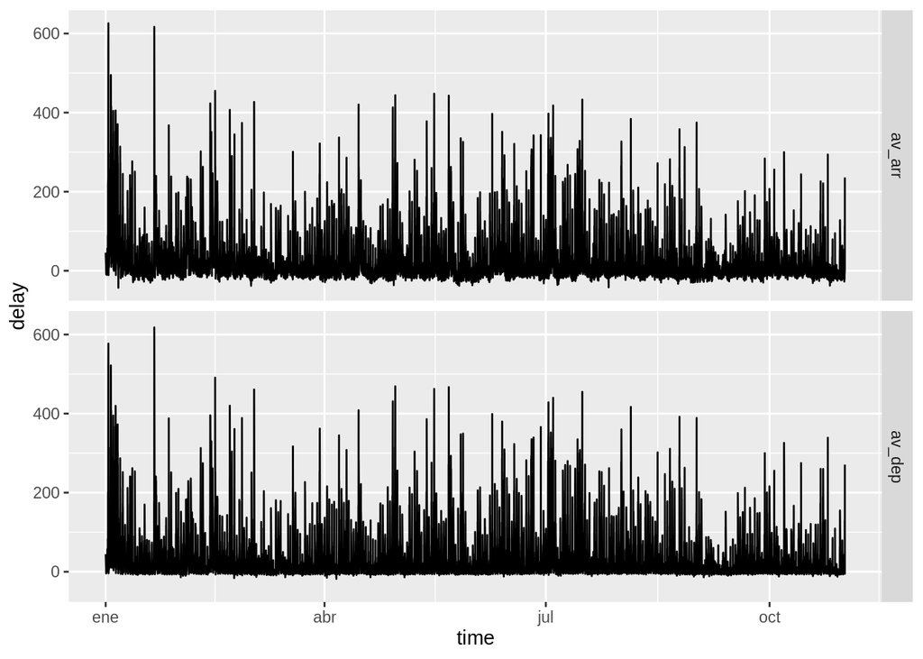

```r
library(tidyr)
av_delays %>% select(av_dep, av_arr, time) %>% gather(arr_dep, delay, -time) %>% ggplot(aes(time, delay)) + geom_line() + facet_grid(arr_dep ~ .)
```